# Sentiment analysis with tidy data

J.H AHN

2022 1 24

# 1 Sentiment analysis with tidy data

이전 장에서 tidy text format을 배웠고, 이 포맷을 이용하여 단어 빈도를 확인할 수 있는 방법을 알아보았다. 이번 장에서는 감정 분석을 다룰 예정이다. 독자들이 텍스트에 접근할 때 단어의 감정적 의도(긍정적인지, 부정적인지, 놀람 혹은 혐오감 등)을 추정한다.

텍스트의 감정을 분석하는 한 가지 방법은 텍스트를 개별 단어의 조합으로 간주하고 전체 텍스트의 감정 내용을 개별 단어의 감정의 합으로 간주하는 것이다. 이 방법이 감정 분석을 위한 유일한 방법은 아니지만 자주 사용되는 접근 방식이고 tidy tool을 사용하기 위한 접근 방법 중 하나이다.

## 1.1 The `sentiments` datasets

위에서 논의한 바와 같이 텍스트에서 의견이나 감정을 평가하기 위한 여러가지 방법과 사전(lexicons)이 있다. `tidytext`package는 여러 감정 어휘에 대한 정보를 아래 세 가지 범용 사전을 통해 파악한다.

- `AFINN` from [Finn Årup Nielsen](http://www2.imm.dtu.dk/pubdb/views/publication_details.php?id=6010),
- `bing` from [Bing Liu and collaborators](https://www.cs.uic.edu/~liub/FBS/sentiment-analysis.html), and
- `nrc` from [Saif Mohammad and Peter Turney](http://saifmohammad.com/WebPages/NRC-Emotion-Lexicon.htm).

이 세 가지 사전은 모두 유니그램, 즉 단일 단어를 기반으로 한다. 이 사전에는 많은 영어단어가 포함되어 있으며 단어에는 긍정적/부정적 감정과 기쁨, 분노, 슬픔 등과 같은 감정에 대한 점수가 할당되어 있다. `nrc` 사전은 단어를 이진 방식(“예”/“아니오”)으로 긍정적, 부정적, 분노, 기대, 혐오, 두려움, 기쁨, 슬픔, 놀람, 신뢰의 범주로 분류한다. `bing` 사전은 단어를 이진 방식으로 긍정적인 범주와 부정적인 범주로 분류한다. ‘AFINN’ 사전은 -5에서 5 사이의 점수로 단어를 할당하며, 부정적인 점수는 부정적인 감정을 나타내고 긍정적인 점수는 긍정적인 감정을 나타낸다.

`get_sentiments()`를 사용하면 각 사전에 있는 감정 데이터를 얻을 수 있다.

```r
library(tidytext)

get_sentiments("afinn")
```

```
## # A tibble: 2,477 x 2
##    word       value
##    <chr>      <dbl>
##  1 abandon       -2
##  2 abandoned     -2
##  3 abandons      -2
##  4 abducted      -2
##  5 abduction     -2
##  6 abductions    -2
##  7 abhor         -3
##  8 abhorred      -3
##  9 abhorrent     -3
## 10 abhors        -3
## # ... with 2,467 more rows
```

```r
get_sentiments("bing")
```

```
## # A tibble: 6,786 x 2
##    word        sentiment
##    <chr>       <chr>
##  1 2-faces     negative
##  2 abnormal    negative
##  3 abolish     negative
##  4 abominable  negative
##  5 abominably  negative
##  6 abominate   negative
##  7 abomination negative
##  8 abort       negative
##  9 aborted     negative
## 10 aborts      negative
## # ... with 6,776 more rows
```

```r
get_sentiments("nrc")
```

```
## # A tibble: 13,875 x 2
##    word        sentiment
##    <chr>       <chr>
##  1 abacus      trust
##  2 abandon     fear
##  3 abandon     negative
##  4 abandon     sadness
##  5 abandoned   anger
##  6 abandoned   fear
##  7 abandoned   negative
##  8 abandoned   sadness
##  9 abandonment anger
## 10 abandonment fear
## # ... with 13,865 more rows
```

이러한 감정 어휘들은 Amazon Mechanical Turk와 같은 클라우드 소싱 또는 저자들이 수집하여 클라우드 소싱, 리뷰, 트위터 데이터 조합을 사용하여 검증하였다. 이런 감정 어휘들을 200년전 쓰여진 소설에 적용하는데는 틀린 부분이 있을 수 있지만 감정을 확인하는데 큰 문제는 없다.

또한 특정 콘텐츠 영역의 텍스트와 함께 사용하도록 구성된 일부 도메인별 감정 어휘를 사용할 수도 있다. 5.3.1장에서는 금융쪽 감정어휘를 사용하여 분석하는 방법이 나와있다.

대다수의 영어 단어는 중립적이기 때문에 모든 영어 단어에 대한 감정이 실려있는 것은 아니다. 이런 방법은 “no good”이나 “not true”와 같이 단어 앞에 있는 한정자를 고려하지 않는다는 사실도 기억해 둬야 한다. 어휘 기반의 방법은 유니그램(단일단어)만을 고려한다. 많은 종류의 텍스트들이 풍자 또는 부정문이 아니므로 한정자를 고려하지 않더라도 큰 문제가 되지 않는다. 또한 주어진 텍스트에서 어떤 종류의 부정어가 중요한지 이해하기 위해 tidy text format을 이용할 수도 있다. 이에 대한 자세한 내용은 9장에서 다룬다.

마지막 주의 사항은 유니그램 감정점수를 합산하는데 사용하는 텍스트의 길이가 분석에 영향을 미칠 수 있다는 것이다. 긴 텍스트의 경우 긍정적인 감정의 평균이 0인 경우가 많고, 문장 단위나 단락 단위의 텍스트가 감정분석에 더 적합한 경우가 많다.

## 1.2 Sentiment analysis with inner join

tidy format의 데이터를 사용하면 `inner_join()`을 사용하여 감정분석을 할 수 있다. 불용어(stopwords)를 제거할 때 `anti_join()`을 사용하는 것처럼 감정분석을 수행할 때는 `inner_join()`을 사용한다.

NRC 사전에서 joy score로 단어를 보자. Emma에서 가장 흔한 기쁨(joy)을 표현하는 단어는 무엇일까? 1.3장에서 했듯이 ’unnest_tokens()`를 사용하여 tidy format으로 변환한다. 또한 각 단어가 책의 어느 챕터의 몇 번째 줄에 나오는지 알기 위해`group_by()`와`mutate()`를 사용하여 새로운 열을 만들어 넣는다.

```r
library(janeaustenr)
library(dplyr)
library(stringr)

tidy_books <- austen_books() %>%
  group_by(book) %>%
  mutate(
    linenumber = row_number(),
    chapter = cumsum(str_detect(text,
                                regex("^chapter [\\divxlc]",
                                      ignore_case = TRUE)))) %>%
  ungroup() %>%
  unnest_tokens(word, text)
```

`unnest_tokens()` argument로 word를 입력했다. 이는 감정 어휘집과 불용어 데이터셍에 ’word’라는 열이 있기 때문에 이후 `inner_join()`과 `anti_join()`을 수행하는 것을 쉽게 만들어 준다.

하나의 행에 하나의 단어가 들어간 형태로 변환되어 감정 분석을 할 준비가 되었다. 먼저 기쁨(joy)을 의미하는 단어를 찾기 위해 NRC에서 `filter()`를 사용한다. 기쁨을 의미하는 단어를 NRC에서 추출하였으면 이제 `inner_join()`을 사용하여 NRC에 있는 기쁨을 의미하는 단어와 동일한 단어가 *Emma*에 얼마나 있는지 `count()`로 확인한다.

```r
nrc_joy <- get_sentiments("nrc") %>%
  filter(sentiment == "joy")

tidy_books %>%
  filter(book == "Emma") %>%
  inner_join(nrc_joy) %>%
  count(word, sort = TRUE)
```

```
## # A tibble: 301 x 2
##    word          n
##    <chr>     <int>
##  1 good        359
##  2 friend      166
##  3 hope        143
##  4 happy       125
##  5 love        117
##  6 deal         92
##  7 found        92
##  8 present      89
##  9 kind         82
## 10 happiness    76
## # ... with 291 more rows
```

[output not shown]

희망, 우정, 사랑에 대한 긍정적이고 행복한 의미의 단어를 볼 수 있다. 또한 “found”, “present”등 긍정적인 의미로 사용하지 않을 수 있는 단어도 볼 수 있다. 이런 단어들은 2.4장에서 자세히 볼 것이다.

각 소설에서 감정이 어떻게 변하는지도 확인할 수 있다. 대부분 dplyr 함수 몇 줄만으로 이런 작업을 수행할 수 있다. 먼저 bing 어휘집과 `inner_join()`을 사용하여 각 단어에 대한 감정 점수를 찾는다.

다음으로 각 책의 섹션마다 얼마나 많은 긍정적인 단어와 부정적인 단어가 있는지 계산한다. 내러티브에서 어디를 보고 있는지 확인하기 위해 인덱스를 만든다. 이 인덱스는 정수 나누기를 이용하고 80줄의 텍스트를 한 섹션으로 본다.

작은 섹션에는 감정을 평가할 적절한 단어가 부족할 수도 있다. 이 책의 경우 80줄을 사용하는 것이 효과적이지만 때에 따라 개별 텍스트나 더 긴 줄이 효과적일 때도 있다. 다음으로 `pivot_wider()`를 사용하여 별도의 열에 부정적인 감정과 긍정적인 감정을 넣는다.

```r
library(tidyr)

jane_austen_sentiment <- tidy_books %>%
  inner_join(get_sentiments("bing")) %>%
  count(book, index = linenumber %/% 80, sentiment) %>%
  pivot_wider(names_from = sentiment, values_from = n, values_fill = 0) %>%
  mutate(sentiment = positive - negative)
```

이제 소설의 줄거리에 따라 감정 점수를 시각화 할 수 있다. 텍스트 섹션에서 내러티브 시간을 추적하는 X축을 ’index’로 둔 점에 주의하여야 한다.

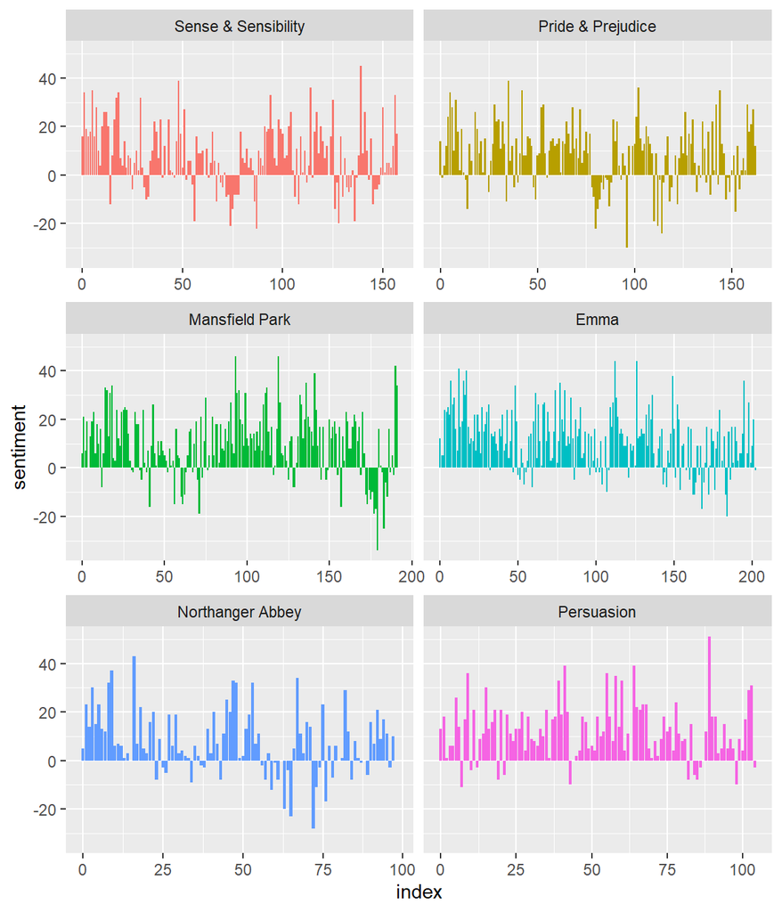

Sentiment through the narratives of Jane Austen’s novels

```r
library(ggplot2)

ggplot(jane_austen_sentiment, aes(index, sentiment, fill = book)) +
  geom_col(show.legend = FALSE) +
  facet_wrap(~book, ncol = 2, scales = "free_x")
```

그림 2.2에서 각 소설의 플롯이 이야기의 전개에 따라 긍정적이거나 부정적인 감정으로 변하는 것을 볼 수 있다.